# F9_03_PROG_DESC

Program service accomplishment · Text report

## Overview

**Description**

Program Accomplishment Description

**Table**

`F9-P03-T00-PROGRAM-TWO` (one)

**Location code**

`F990-PC-PART-03-LINE-04-ABCD`, `F990-EZ-PART-03-LINE-28-31`

**Family**

`F990-PC-PART-03-LINE-04-ABCD` · siblings: F9_03_PROG_CODE, F9_03_PROG_EXP, F9_03_PROG_GRANT, F9_03_PROG_REV, F9_03_PROG_EXP_OTH_TOT, F9_03_PROG_GRANT_OTH_TOT

**Data type**

text (xsd: ExplanationType, )

**Scope**

PZ

**Status**

unreviewed

18

xpaths mapped (10 observed)

8,429,949

filings with a value

2009–2024

tax years observed

17

open flags (1 errors)

## Flags

[output not shown]

## Xpaths

All mapped xpaths (under /Return/ReturnData or /Return/ReturnHeader), oldest first. Charts label each series by its xpath.

| Xpath | Form | Chart label | First year | Last year | Versions | Filings | Repeats in |
| --- | --- | --- | --- | --- | --- | --- | --- |
| IRS990/Description | 990 | same | 2009 | 2012 | 19 | 495,528 | 0.0% |
| IRS990EZ/ProgramServiceAccomplishment/DescriptionProgramServiceAccom | 990-EZ | …ogramServiceAccomplishment/DescriptionProgramServiceAccom | 2009 | 2012 | 18 | 254,594 | 27.3% |
| IRS990/Activity2/Description | 990 | same | 2009 | 2012 | 18 | 158,068 | 0.0% |
| IRS990/Activity3/Description | 990 | same | 2009 | 2012 | 18 | 113,303 | 0.0% |
| IRS990/ActivityOther/Description | 990 | same | 2009 | 2012 | 16 | 68,286 | 17.6% |
| IRS990/Desc | 990 | same | 2013 | 2024 | 38 | 3,349,613 | 0.0% |
| IRS990EZ/ProgramSrvcAccomplishmentGrp/DescriptionProgramSrvcAccomTxt | 990-EZ | …ogramSrvcAccomplishmentGrp/DescriptionProgramSrvcAccomTxt | 2013 | 2024 | 38 | 1,881,301 | 28.2% |
| IRS990/Form990PartIII/Activity2/Description | 990 | Other |  |  |  | 0 |  |
| IRS990/Form990PartIII/Activity3/Description | 990 | Other |  |  |  | 0 |  |
| IRS990/Form990PartIII/ActivityOther/Description | 990 | Other |  |  |  | 0 |  |
| IRS990/Form990PartIII/Description | 990 | Other |  |  |  | 0 |  |
| IRS990/ProgSrvcAccomActy2Grp/Desc | 990 | Other | 2013 | 2024 | 38 | 992,253 | 0.0% |
| IRS990/ProgSrvcAccomActy3Grp/Desc | 990 | Other | 2013 | 2024 | 38 | 692,458 | 0.0% |
| IRS990/ProgSrvcAccomActyOtherGrp/Desc | 990 | Other | 2013 | 2024 | 36 | 424,545 | 12.8% |
| IRS990/ProgramServiceAccomplishments/DescriptionProgramServiceAccom | 990 | Other |  |  |  | 0 |  |
| IRS990EZ/ProgSrvcAccomActy2Grp/Desc | 990-EZ | Other |  |  |  | 0 |  |
| IRS990EZ/ProgSrvcAccomActy3Grp/Desc | 990-EZ | Other |  |  |  | 0 |  |
| IRS990EZ/ProgSrvcAccomActyOtherGrp/Desc | 990-EZ | Other |  |  |  | 0 |  |

## Coverage

[figure not shown]

**Table view**

Table view: filings by tax year and series

| Tax year | IRS990/Description | …ogramServiceAccomplishment/DescriptionProgramServiceAccom | IRS990/Activity2/Description | IRS990/Activity3/Description | IRS990/ActivityOther/Description | IRS990/Desc | …ogramSrvcAccomplishmentGrp/DescriptionProgramSrvcAccomTxt | Other |
| --- | --- | --- | --- | --- | --- | --- | --- | --- |
| 2009 | 33,311 | 15,470 | 12,321 | 9,361 | 5,457 | 0 | 0 | 0 |
| 2010 | 123,025 | 63,326 | 39,215 | 28,264 | 16,765 | 0 | 0 | 0 |
| 2011 | 159,504 | 82,048 | 50,336 | 35,855 | 21,485 | 0 | 0 | 0 |
| 2012 | 179,688 | 93,750 | 56,196 | 39,823 | 24,579 | 0 | 0 | 0 |
| 2013 | 0 | 0 | 0 | 0 | 0 | 198,855 | 104,375 | 131,912 |
| 2014 | 0 | 0 | 0 | 0 | 0 | 218,619 | 116,417 | 142,877 |
| 2015 | 0 | 0 | 0 | 0 | 0 | 233,519 | 124,894 | 150,927 |
| 2016 | 0 | 0 | 0 | 0 | 0 | 243,903 | 130,484 | 156,653 |
| 2017 | 0 | 0 | 0 | 0 | 0 | 261,612 | 139,145 | 166,455 |
| 2018 | 0 | 0 | 0 | 0 | 0 | 271,442 | 149,384 | 170,554 |
| 2019 | 0 | 0 | 0 | 0 | 0 | 283,694 | 152,623 | 178,008 |
| 2020 | 0 | 0 | 0 | 0 | 0 | 320,343 | 169,865 | 199,647 |
| 2021 | 0 | 0 | 0 | 0 | 0 | 336,488 | 202,729 | 208,304 |
| 2022 | 0 | 0 | 0 | 0 | 0 | 349,062 | 206,135 | 215,714 |
| 2023 | 0 | 0 | 0 | 0 | 0 | 354,774 | 206,382 | 218,739 |
| 2024 | 0 | 0 | 0 | 0 | 0 | 277,302 | 178,868 | 169,466 |

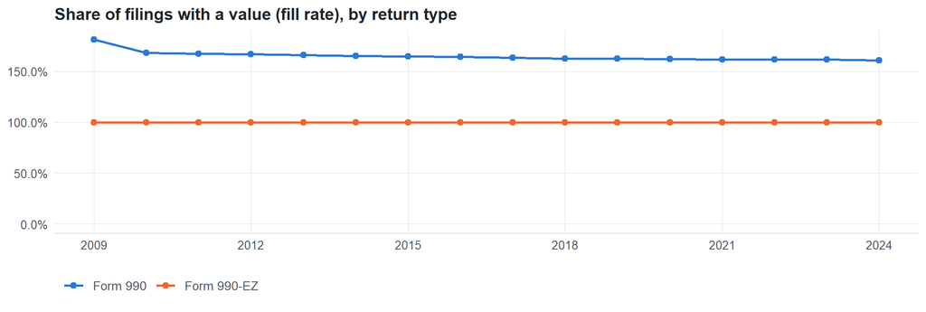

**Table view**

Table view: fill rate

| Tax year | Return type | Filings | All filings | Fill rate |
| --- | --- | --- | --- | --- |
| 2009 | Form 990 | 60,450 | 33,311 | 181.47% |
| 2009 | Form 990-EZ | 15,470 | 15,470 | 100.00% |
| 2010 | Form 990 | 207,269 | 123,025 | 168.48% |
| 2010 | Form 990-EZ | 63,326 | 63,326 | 100.00% |
| 2011 | Form 990 | 267,180 | 159,504 | 167.51% |
| 2011 | Form 990-EZ | 82,048 | 82,048 | 100.00% |
| 2012 | Form 990 | 300,286 | 179,688 | 167.12% |
| 2012 | Form 990-EZ | 93,750 | 93,750 | 100.00% |
| 2013 | Form 990 | 330,767 | 198,855 | 166.34% |
| 2013 | Form 990-EZ | 104,375 | 104,375 | 100.00% |
| 2014 | Form 990 | 361,496 | 218,619 | 165.35% |
| 2014 | Form 990-EZ | 116,417 | 116,417 | 100.00% |
| 2015 | Form 990 | 384,446 | 233,519 | 164.63% |
| 2015 | Form 990-EZ | 124,894 | 124,894 | 100.00% |
| 2016 | Form 990 | 400,556 | 243,903 | 164.23% |
| 2016 | Form 990-EZ | 130,484 | 130,484 | 100.00% |
| 2017 | Form 990 | 428,067 | 261,612 | 163.63% |
| 2017 | Form 990-EZ | 139,144 | 139,144 | 100.00% |
| 2018 | Form 990 | 441,996 | 271,442 | 162.83% |
| 2018 | Form 990-EZ | 149,384 | 149,384 | 100.00% |
| 2019 | Form 990 | 461,702 | 283,694 | 162.75% |
| 2019 | Form 990-EZ | 152,622 | 152,622 | 100.00% |
| 2020 | Form 990 | 519,987 | 320,342 | 162.32% |
| 2020 | Form 990-EZ | 169,864 | 169,864 | 100.00% |
| 2021 | Form 990 | 544,778 | 336,480 | 161.91% |
| 2021 | Form 990-EZ | 202,724 | 202,724 | 100.00% |
| 2022 | Form 990 | 564,768 | 349,055 | 161.80% |
| 2022 | Form 990-EZ | 206,130 | 206,130 | 100.00% |
| 2023 | Form 990 | 573,507 | 354,768 | 161.66% |
| 2023 | Form 990-EZ | 206,379 | 206,379 | 100.00% |
| 2024 | Form 990 | 446,762 | 277,298 | 161.11% |
| 2024 | Form 990-EZ | 178,867 | 178,867 | 100.00% |

## Repeating groups

Table cardinality in the concordance: **one**. 4 of 10 observed xpaths repeat within a filing.

Repeating element each xpath was observed in (from the raw indexed xpath)

| Xpath | Repeating element | Filings (summed over years) |
| --- | --- | --- |
| IRS990/Activity2/Description | (none) | 158068 |
| IRS990/Activity3/Description | (none) | 113303 |
| IRS990/ActivityOther/Description | (none) | 56244 |
| IRS990/ActivityOther/Description | IRS990/ActivityOther | 12042 |
| IRS990/Description | (none) | 495528 |
| IRS990EZ/ProgramServiceAccomplishment/DescriptionProgramServiceAccom | (none) | 185084 |
| IRS990EZ/ProgramServiceAccomplishment/DescriptionProgramServiceAccom | IRS990EZ/ProgramServiceAccomplishment | 69510 |
| IRS990/Desc | (none) | 3349613 |
| IRS990/ProgSrvcAccomActy2Grp/Desc | (none) | 992253 |
| IRS990/ProgSrvcAccomActy3Grp/Desc | (none) | 692458 |
| IRS990/ProgSrvcAccomActyOtherGrp/Desc | (none) | 369930 |
| IRS990/ProgSrvcAccomActyOtherGrp/Desc | IRS990/ProgSrvcAccomActyOtherGrp | 54615 |
| IRS990EZ/ProgramSrvcAccomplishmentGrp/DescriptionProgramSrvcAccomTxt | (none) | 1351433 |
| IRS990EZ/ProgramSrvcAccomplishmentGrp/DescriptionProgramSrvcAccomTxt | IRS990EZ/ProgramSrvcAccomplishmentGrp | 529868 |

## Values

[output not shown]

[figure not shown]

**Table view**

Table view: length and variety by tax year

| Series | Tax year | Filings | Avg length | Max length | Distinct values (approx.) |
| --- | --- | --- | --- | --- | --- |
| IRS990/Description | 2009 | 33,311 | 411 | 9,000 | 27,678 |
| IRS990/Description | 2010 | 123,025 | 320 | 9,000 | 53,022 |
| IRS990/Description | 2011 | 159,504 | 316 | 9,000 | 116,297 |
| IRS990/Description | 2012 | 179,688 | 321 | 9,000 | 95,293 |
| …ogramServiceAccomplishment/DescriptionProgramServiceAccom | 2009 | 15,470 | 170 | 8,762 | 12,361 |
| …ogramServiceAccomplishment/DescriptionProgramServiceAccom | 2010 | 63,326 | 160 | 8,693 | 55,277 |
| …ogramServiceAccomplishment/DescriptionProgramServiceAccom | 2011 | 82,048 | 155 | 8,859 | 91,836 |
| …ogramServiceAccomplishment/DescriptionProgramServiceAccom | 2012 | 93,750 | 155 | 9,000 | 56,935 |
| IRS990/Activity2/Description | 2009 | 12,321 | 375 | 9,000 | 9,008 |
| IRS990/Activity2/Description | 2010 | 39,215 | 327 | 9,000 | 21,371 |
| IRS990/Activity2/Description | 2011 | 50,336 | 328 | 9,000 | 38,042 |
| IRS990/Activity2/Description | 2012 | 56,196 | 334 | 9,000 | 39,696 |
| IRS990/Activity3/Description | 2009 | 9,361 | 372 | 9,000 | 5,901 |
| IRS990/Activity3/Description | 2010 | 28,264 | 329 | 9,000 | 12,611 |
| IRS990/Activity3/Description | 2011 | 35,855 | 330 | 9,000 | 28,568 |
| IRS990/Activity3/Description | 2012 | 39,823 | 336 | 9,000 | 25,579 |
| IRS990/ActivityOther/Description | 2009 | 5,457 | 259 | 8,910 | 8,463 |
| IRS990/ActivityOther/Description | 2010 | 16,765 | 253 | 8,999 | 19,360 |
| IRS990/ActivityOther/Description | 2011 | 21,485 | 251 | 9,000 | 22,033 |
| IRS990/ActivityOther/Description | 2012 | 24,579 | 257 | 9,000 | 23,853 |
| IRS990/Desc | 2013 | 198,855 | 325 | 9,000 | 79,067 |
| IRS990/Desc | 2014 | 218,619 | 329 | 9,000 | 149,989 |
| IRS990/Desc | 2015 | 233,519 | 333 | 9,000 | 124,725 |
| IRS990/Desc | 2016 | 243,903 | 337 | 9,000 | 255,455 |
| IRS990/Desc | 2017 | 261,612 | 340 | 9,000 | 168,004 |
| IRS990/Desc | 2018 | 271,442 | 339 | 9,000 | 209,718 |
| IRS990/Desc | 2019 | 283,694 | 344 | 9,000 | 116,507 |
| IRS990/Desc | 2020 | 320,343 | 342 | 9,002 | 117,671 |
| IRS990/Desc | 2021 | 336,488 | 337 | 9,000 | 153,321 |
| IRS990/Desc | 2022 | 349,062 | 337 | 9,004 | 319,382 |
| IRS990/Desc | 2023 | 354,774 | 339 | 9,002 | 124,997 |
| IRS990/Desc | 2024 | 277,302 | 325 | 9,000 | 95,504 |
| …ogramSrvcAccomplishmentGrp/DescriptionProgramSrvcAccomTxt | 2013 | 104,375 | 157 | 9,000 | 84,483 |
| …ogramSrvcAccomplishmentGrp/DescriptionProgramSrvcAccomTxt | 2014 | 116,417 | 158 | 9,000 | 139,746 |
| …ogramSrvcAccomplishmentGrp/DescriptionProgramSrvcAccomTxt | 2015 | 124,894 | 159 | 9,002 | 113,536 |
| …ogramSrvcAccomplishmentGrp/DescriptionProgramSrvcAccomTxt | 2016 | 130,484 | 160 | 9,000 | 186,009 |
| …ogramSrvcAccomplishmentGrp/DescriptionProgramSrvcAccomTxt | 2017 | 139,145 | 160 | 9,000 | 116,192 |
| …ogramSrvcAccomplishmentGrp/DescriptionProgramSrvcAccomTxt | 2018 | 149,384 | 160 | 9,000 | 194,119 |
| …ogramSrvcAccomplishmentGrp/DescriptionProgramSrvcAccomTxt | 2019 | 152,623 | 161 | 9,000 | 128,699 |
| …ogramSrvcAccomplishmentGrp/DescriptionProgramSrvcAccomTxt | 2020 | 169,865 | 162 | 9,000 | 135,956 |
| …ogramSrvcAccomplishmentGrp/DescriptionProgramSrvcAccomTxt | 2021 | 202,729 | 157 | 9,000 | 144,828 |
| …ogramSrvcAccomplishmentGrp/DescriptionProgramSrvcAccomTxt | 2022 | 206,135 | 157 | 9,000 | 281,344 |
| …ogramSrvcAccomplishmentGrp/DescriptionProgramSrvcAccomTxt | 2023 | 206,382 | 159 | 9,000 | 131,123 |
| …ogramSrvcAccomplishmentGrp/DescriptionProgramSrvcAccomTxt | 2024 | 178,868 | 164 | 9,000 | 115,772 |
| Other | 2013 | 131,912 | 317 | 9,000 | 23,307 |
| Other | 2014 | 142,877 | 322 | 9,000 | 48,001 |
| Other | 2015 | 150,927 | 328 | 9,000 | 40,467 |
| Other | 2016 | 156,653 | 333 | 9,000 | 76,189 |
| Other | 2017 | 166,455 | 336 | 9,000 | 58,624 |
| Other | 2018 | 170,554 | 337 | 9,000 | 72,010 |
| Other | 2019 | 178,008 | 341 | 9,000 | 39,542 |
| Other | 2020 | 199,647 | 339 | 9,000 | 35,211 |
| Other | 2021 | 208,304 | 332 | 9,000 | 51,004 |
| Other | 2022 | 215,714 | 333 | 9,000 | 88,096 |
| Other | 2023 | 218,739 | 334 | 9,000 | 39,757 |
| Other | 2024 | 169,466 | 314 | 9,000 | 37,879 |

Most common values by xpath (all years; long values truncated)

| Series | Value | Filings | Share |
| --- | --- | --- | --- |
| IRS990/Description | N/A | 1,881 | 0.4% |
| IRS990/Description | SEE SCHEDULE O | 1,441 | 0.3% |
| IRS990/Description | THE SOLE PURPOSE IS TO PROVIDE SUBSIDIZED LOW AND MODERATE-INCOME APARTMENT RENTAL HOUSING FOR PRIMA | 542 | 0.1% |
| IRS990/Description | NONE | 475 | 0.1% |
| IRS990/Description | SEE SCHEDULE O. | 359 | 0.1% |
| IRS990/Description | TO PROVIDE ACCESSIBLE HOUSING FOR ADULTS WITH DISABILITIES AND SENIORS. ALSO TO PROVIDE SUPPORTIVE C | 301 | 0.1% |
| IRS990/Description | Title Holding Corporation for Real Property | 298 | 0.1% |
| IRS990/Description | See Schedule O | 271 | 0.1% |
| IRS990/Description | . | 192 | 0.0% |
| IRS990/Description | PROVIDES HOUSING TO ELDERLY AND DISABLED PERSONS AND FAMILIES UNDER SECTION 202 OF THE NATIONAL HOUS | 131 | 0.0% |
| IRS990/Description | POLICY DEVELOPMENT- MEMBERS WORKING IN COMMITTEES INVOLVED AT THE COUNTY, DISTRICT AND STATE LEVELS | 63 | 0.0% |
| IRS990/Description | See Schedule O. | 26 | 0.0% |
| IRS990/Description | WHEATON FRANCISCAN SERVICES, INC. (WFSI) is a Catholic, not-for-profit health care and housing organ | 23 | 0.0% |
| IRS990/Description | Under the Medical Service Plan of the University of Maryland, School of Medicine, medical services a | 20 | 0.0% |
| IRS990/Description | SEE SCHEDULE H | 19 | 0.0% |
| …ogramServiceAccomplishment/DescriptionProgramServiceAccom | N/A | 1,230 | 0.5% |
| …ogramServiceAccomplishment/DescriptionProgramServiceAccom | NONE | 934 | 0.4% |
| …ogramServiceAccomplishment/DescriptionProgramServiceAccom | 0 | 652 | 0.3% |
| …ogramServiceAccomplishment/DescriptionProgramServiceAccom | Other program services | 529 | 0.2% |
| …ogramServiceAccomplishment/DescriptionProgramServiceAccom | SCHOLARSHIPS | 483 | 0.2% |
| …ogramServiceAccomplishment/DescriptionProgramServiceAccom | None | 475 | 0.2% |
| …ogramServiceAccomplishment/DescriptionProgramServiceAccom | TO FURTHER THE INTERESTS OF ITS MEMBERSHIP BY SEEKING IMPROVED TERMS AND CONDITIONS OF EMPLOYMENT, T | 450 | 0.2% |
| …ogramServiceAccomplishment/DescriptionProgramServiceAccom | SEE SCHEDULE O | 437 | 0.2% |
| …ogramServiceAccomplishment/DescriptionProgramServiceAccom | TO PROMOTE, PROTECT AND REPRESENT THE BUSINESS, SOCIAL AND EDUCATIONAL INTEREST OF THE FARMERS OF TH | 231 | 0.1% |
| …ogramServiceAccomplishment/DescriptionProgramServiceAccom | See Schedule O | 81 | 0.0% |
| …ogramServiceAccomplishment/DescriptionProgramServiceAccom | SOCIAL: FORMAL AND INFORMAL SOCIAL EVENTS ARE HELD ALLOWING MEMBERSHIP TO CONNECT. | 66 | 0.0% |
| …ogramServiceAccomplishment/DescriptionProgramServiceAccom | SOCIAL | 65 | 0.0% |
| …ogramServiceAccomplishment/DescriptionProgramServiceAccom | RECRUITMENT | 64 | 0.0% |
| …ogramServiceAccomplishment/DescriptionProgramServiceAccom | COLLEGIATE SOCIAL FRATERNITY | 46 | 0.0% |
| …ogramServiceAccomplishment/DescriptionProgramServiceAccom | The Organization provides group housing for people suffering from mental illness. | 25 | 0.0% |

First rows shown.

## Examples

| Tax year | Return | Xpath | Organization | Value | Source |
| --- | --- | --- | --- | --- | --- |
| 2024 | 990 | IRS990/Desc | IAAI FOUNDATION INC | SCHOLARSHIPS AWARDED TO 7 INDIVIDUALS | [XML](https://gt990datalake-rawdata.s3.amazonaws.com/EfileData/XmlFiles/202523089349301317_public.xml) |
| 2024 | 990 | IRS990/ProgSrvcAccomActy2Grp/Desc | IAAI FOUNDATION INC | SUPPORT TRAINING AND PROFESSIONAL DEVELOPMENT PROGRAMS CONSISTENT WITH THE PURPOSES OF THE FOUNDATIO | [XML](https://gt990datalake-rawdata.s3.amazonaws.com/EfileData/XmlFiles/202523089349301317_public.xml) |
| 2024 | 990 | IRS990/ProgSrvcAccomActy3Grp/Desc | RISEWELL COMMUNITY SERVICES INC FKA | CONSUMER AFFAIRS - OUR CONSUMER AFFAIRS DIVISION CONSISTS OF A VARIETY OF SERVICES DELIVERED TO MENT | [XML](https://gt990datalake-rawdata.s3.amazonaws.com/EfileData/XmlFiles/202610589349301811_public.xml) |
| 2024 | 990 | IRS990/ProgSrvcAccomActyOtherGrp/Desc | OWL CREEK COUNTRY CLUB | ENTERTAINMENT, FOOD, BEVERAGE, AND RECREATION FOR MEMBERS | [XML](https://gt990datalake-rawdata.s3.amazonaws.com/EfileData/XmlFiles/202513219349315726_public.xml) |
| 2024 | 990EZ | IRS990EZ/ProgramSrvcAccomplishmentGrp/DescriptionProgramSrvcAccomTxt | THE CREATIVES PROJECT INC | . Completed 60 ours of artistic outreach activities with homeless youth | [XML](https://gt990datalake-rawdata.s3.amazonaws.com/EfileData/XmlFiles/202510859349201521_public.xml) |
| 2023 | 990 | IRS990/Desc | MACKINAC ASSOCIATES | PARK PROJECTS & IMPROVEMENTS - PROVIDES SUPPORT FOR THE PRESERVATION AND PRESENTATION OF HISTORIC AN | [XML](https://gt990datalake-rawdata.s3.amazonaws.com/EfileData/XmlFiles/202530469349300808_public.xml) |
| 2023 | 990 | IRS990/ProgSrvcAccomActy2Grp/Desc | WINNING WHEELS INC | LYNDON HOUSES THE VOCATIONAL AND DEVELOPMENTAL TRAINING PROGRAMS AND THE PLAY AND LEARN CENTER (““““CHI | [XML](https://gt990datalake-rawdata.s3.amazonaws.com/EfileData/XmlFiles/202500939349300530_public.xml) |
| 2023 | 990 | IRS990/ProgSrvcAccomActy3Grp/Desc | Changing Tides Family Services | Changing Tides Family Services provided 3,305 hours of mental health services to over 81 children, y | [XML](https://gt990datalake-rawdata.s3.amazonaws.com/EfileData/XmlFiles/202530989349300133_public.xml) |
| 2023 | 990 | IRS990/ProgSrvcAccomActyOtherGrp/Desc | SOUTHLAKE WOMEN’S CLUB FOUNDATION | CONTRIBUTIONS ARE MADE TO VARIOUS CHARITABLE ORGANIZATIONS AND LOCAL SCHOOLS WITH THE FUNDS GENERATE | [XML](https://gt990datalake-rawdata.s3.amazonaws.com/EfileData/XmlFiles/202413189349310091_public.xml) |
| 2023 | 990EZ | IRS990EZ/ProgramSrvcAccomplishmentGrp/DescriptionProgramSrvcAccomTxt | SAN ANTONIO HOMESCHOOL ATHLETIC ASSOICATION | Support Wolverine Club composed of 9 plus homeschool players from the San Antonio and surrounding ar | [XML](https://gt990datalake-rawdata.s3.amazonaws.com/EfileData/XmlFiles/202432609349201843_public.xml) |
| 2022 | 990 | IRS990/Desc | MERRILL COMMUNITY HOMELESS CENTER INC | TO PROVIDE SHELTER TO THE HOMELESS COMMUNITY IN MERRILL WI | [XML](https://gt990datalake-rawdata.s3.amazonaws.com/EfileData/XmlFiles/202331589349300003_public.xml) |
| 2022 | 990 | IRS990/ProgSrvcAccomActy2Grp/Desc | ILLINOIS ASSOCIATION OF NURSE | NEWSLETTERS ARE PUBLISHED TO DISSEMINATE INFORMAITON TO MEMBERS ABOUT UPCOMING MEETINGS AND CURRENT | [XML](https://gt990datalake-rawdata.s3.amazonaws.com/EfileData/XmlFiles/202432269349302383_public.xml) |

## Reviewer checklist

- The definition matches the form line and instructions for every xpath’s schema years.
- Every xpath pooled here measures the same thing on the 990 and 990-EZ (close enough for analysis).
- The coverage chart has no unexplained gaps or jumps between tax years.
- Each open flag is fixed, or accepted with a note in validation_log.csv.
- Values answer the question on the form line (not another line’s explanation).
- Boilerplate such as ‘See Schedule O’ or ‘N/A’ is expected here, or should be treated as missing.
- Text that is really a number or a code is flagged for a different data type.

Record the review as a row in `inst/extdata/src/validation_log.csv` (variable_name, reviewer, date, status, note). Evidence built 2026-09-23 17:09:04 MST from the ef2 DuckDB builds (tax years 2009–2024).